# Exploring the BRFSS data

## Setup

### Load packages

```r
library(tidyverse)
```

### Load data

```r
load("brfss2013.RData")
```

## Part 1: Data

The Behavioral Risk Factor Surveillance System (BRFSS) is a phone survey conducted by the CDC in all 50 states and US outlying territories. Respondents are randomly selected, non-institutionalized, adults (18+ only) who picked up land-line or cellphones and took the survey. This is a retrospective observational study with random sampling and not an experiment with random assignment therefore we can assume generalization (with some caveats) but NOT causation. If the study is generalized to the US population as a whole several biases exist: prisoners, children, and those without phones are not included. This study is better generalized to the non-institutionalized, phone-owning, adult population of the US. There is also an opportunity for non-response sample bias as not everyone randomly sampled will respond to a phone survey, especially one with enough questions to create 330 variables. If the non-response bias is strong enough that the sample is no longer representative then the study cannot be generalized to the population.

Here I peeked at the data set

```r
# glimpse(brfss2013)
```

## Part 2: Research questions

**Research question 1:** I have been having trouble getting my eight hours of sleep recently. Are hours of sleep per night and health outcomes are correlated?

**Research question 2:** Is there a correlation between time spent working vs sleeping and health outcomes?

**Research question 3:** Is there a correlation between hours of exercise per week, as defined by a sum of the reported average number of hours spent on respondents two most frequent exercise activities per week, and health outcomes?

## Part 3: Exploratory data analysis

**Data Preparation**

I selected the variables on respondents self evaluation of health, reported hours of sleep per 24 hour period, reported hours of work per week, reported weekly frequency of two different exercise activities, and the usual duration of each.

```r
project_d_f <- brfss2013 %>%
  select(general_health = genhlth, sleep_per_day_hrs = sleptim1, work_per_week_hrs = scntlwk1, activity1_freq = exeroft1, activity2_freq = exeroft2, activity1_duration_hmm = exerhmm1, activity2_duration_hmm = exerhmm2)
```

First I took a look at the values of categorical variable General Health.

```r
project_d_f %>%
  group_by(general_health) %>%
  summarize(count = n())
```

```
## # A tibble: 6 x 2
##   general_health  count
##   <fct>           <int>
## 1 Excellent       85482
## 2 Very good      159076
## 3 Good           150555
## 4 Fair            66726
## 5 Poor            27951
## 6 <NA>             1985
```

I would like the factors of general health to be ordered from worst to best so I reversed the order and checked to make sure it worked.

```r
project_d_f <- project_d_f %>%
  mutate(general_health = factor(general_health, levels = c("Poor", "Fair", "Good", "Very good", "Excellent")))

# check to make sure it worked
project_d_f %>%
  group_by(general_health) %>%
  summarize(count = n())
```

```
## # A tibble: 6 x 2
##   general_health  count
##   <fct>           <int>
## 1 Poor            27951
## 2 Fair            66726
## 3 Good           150555
## 4 Very good      159076
## 5 Excellent       85482
## 6 <NA>             1985
```

Next sleep_per_day_hrs a numerical variable. I created a histogram and five number summary printout.

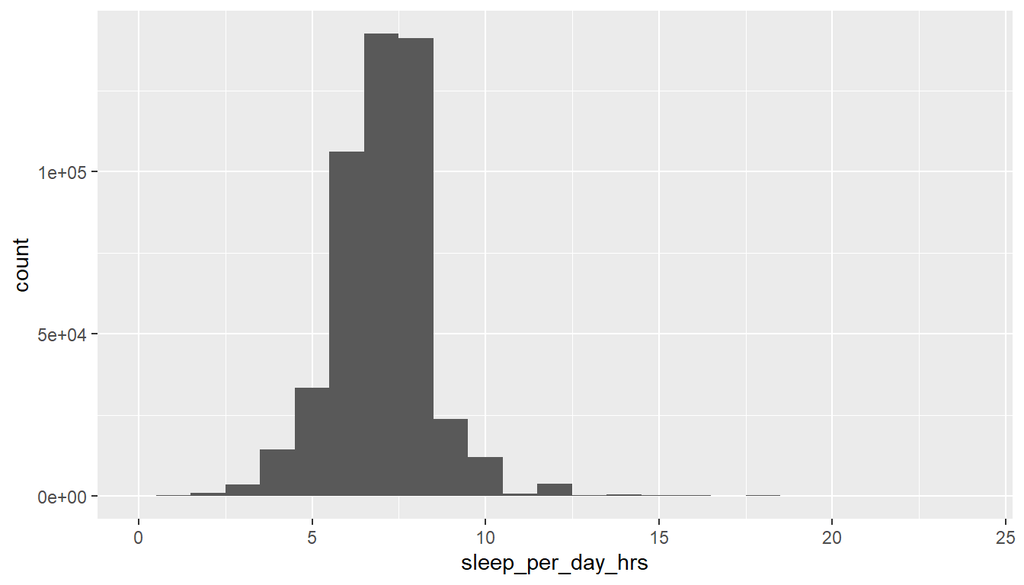

```r
project_d_f %>%
  ggplot(aes(x = sleep_per_day_hrs)) +
  geom_histogram(binwidth = 1) +
  xlim(0, 24)
```

```r
project_d_f %>%
  select(sleep_per_day_hrs) %>%
  filter(!is.na(sleep_per_day_hrs)) %>%
  summarize(Title = "sleep_per_day_hrs", n = n(), min = min(sleep_per_day_hrs), Q1 = quantile(sleep_per_day_hrs, 0.25), median = median(sleep_per_day_hrs), Q3 = quantile(sleep_per_day_hrs, 0.75), max = max(sleep_per_day_hrs))
```

```
##               Title      n min Q1 median Q3 max
## 1 sleep_per_day_hrs 484388   0  6      7  8 450
```

From the five number summary I could see some responses were nonsensical. It is not possible to sleep more than 24 hours in a 24 hour period. Here I set these values to NA.

```r
project_d_f <- project_d_f %>%
  mutate(sleep_per_day_hrs = if_else(sleep_per_day_hrs <= 24, sleep_per_day_hrs, as.integer(NA)))
# NA must be typecast as integer for code to work
```

**Research question 1:**

To attempt to answer question 1 I plotted the data for sleep_per_day_hours and general_health. This faceted histogram shows how the distributions of sleep_per_day_hours for each factor in general_health. In order to show more of the bulk of the distribution some outliers are cropped out by the scaling of the plot.

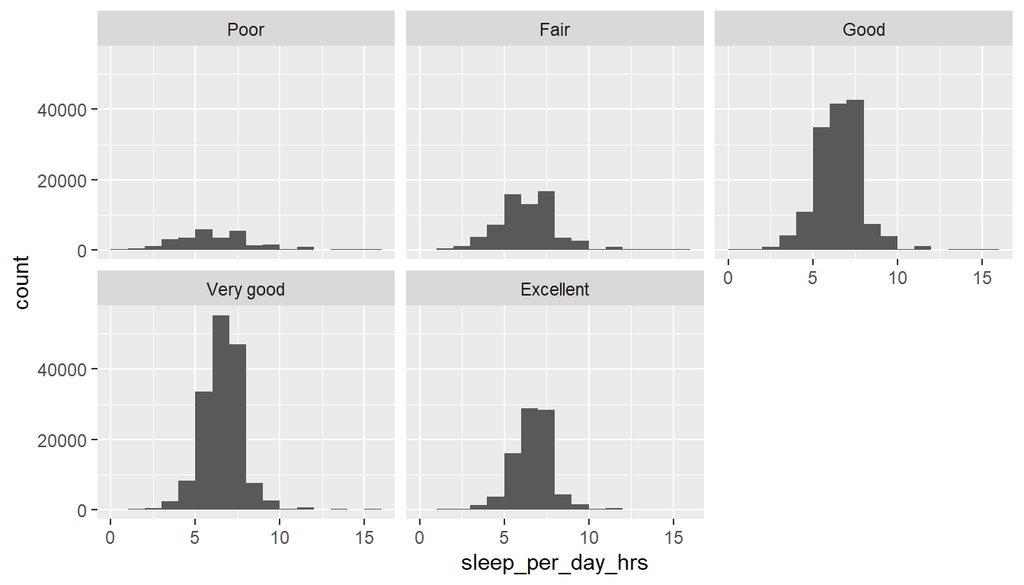

```r
project_d_f %>%
  select(general_health, sleep_per_day_hrs) %>%
  filter(!is.na(general_health) & !is.na(sleep_per_day_hrs)) %>%
  ggplot(aes(x = sleep_per_day_hrs)) +
    geom_histogram(binwidth = 1, boundary = 0) +
    xlim(0,16) +
    facet_wrap(~ general_health)
```

The data is roughly evenly distributed with some slight right skew caused by outliers above the center.

These side by side box-plots display the summary statistics of sleep_per_day_hours for each health outcome. In order to show more of the boxes in more detail the distribution some outliers are cropped out by the scaling of the plot.

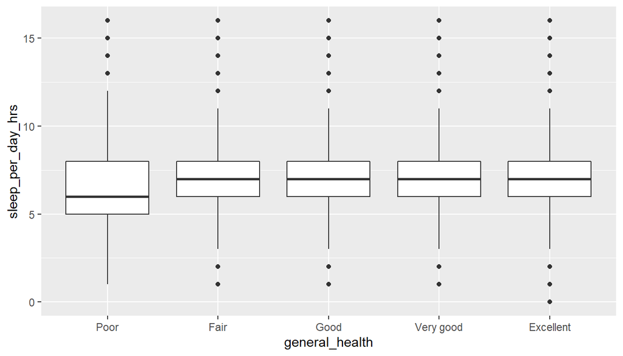

```r
project_d_f %>%
  select(general_health, sleep_per_day_hrs) %>%
  filter(!is.na(general_health) & !is.na(sleep_per_day_hrs)) %>%
  ggplot(mapping = aes(x = general_health, y = sleep_per_day_hrs)) +
    geom_boxplot() +
    ylim(0, 16)
```

Here are the summary statistics of sleep_per_day_hours for each health outcome.

```r
project_d_f %>%
  select(general_health, sleep_per_day_hrs) %>%
  filter(!is.na(general_health) & !is.na(sleep_per_day_hrs)) %>%
  group_by(general_health) %>%
  summarize(n = n(), min = min(sleep_per_day_hrs), Q1 = quantile(sleep_per_day_hrs, 0.25), median = median(sleep_per_day_hrs), mean = mean(sleep_per_day_hrs) %>% round(1), Q3 = quantile(sleep_per_day_hrs, 0.75), max = max(sleep_per_day_hrs), IQR = IQR(sleep_per_day_hrs), sd = sd(sleep_per_day_hrs))
```

```
## # A tibble: 5 x 10
##   general_health      n   min    Q1 median  mean    Q3   max   IQR    sd
##   <fct>           <int> <int> <dbl>  <dbl> <dbl> <dbl> <int> <dbl> <dbl>
## 1 Poor            26639     1     5      6   6.7     8    24     3  2.39
## 2 Fair            65012     1     6      7   6.9     8    24     2  1.81
## 3 Good           148299     1     6      7   7       8    24     2  1.44
## 4 Very good      157833     1     6      7   7.1     8    24     2  1.21
## 5 Excellent       84822     0     6      7   7.2     8    24     2  1.21
```

We can see from the data that there does not appear to be any strong correlation between sleep per night and health outcomes. The mean does show a slight positive correlation between sleep and health. This is however not reflected in the more robust median, except when it jumps from 6 to 7 going from “Poor” health to “Fair” health. It is worth noting that the spread of hours of sleep is higher than any other response, by both standard deviation and IQR, which is likely, at least in part, attributable to the number of “Poor” responses being less than half that of the next least popular response. To answer the question I’d say there is a very weak correlation between hours of sleep and reported health.

Again, this was a retrospective observational study with random sampling and not an experiment with random assignment therefore I did not assume causation. The relationship in the variables may be caused by a confounding variable. It is also worth noting potential issues with this data and assumptions made. In this case there were some extreme responses for hours slept, including multiple respondents who reported sleeping 24 hours a day (Which I’d argue would make it difficult to answer a phone survey), and we are relying on each respondents own self evaluation of health.

**Research question 2:**

Question 2 required comparing sleep and work. I started by taking a look at the hours of work per week to look for potential issues.

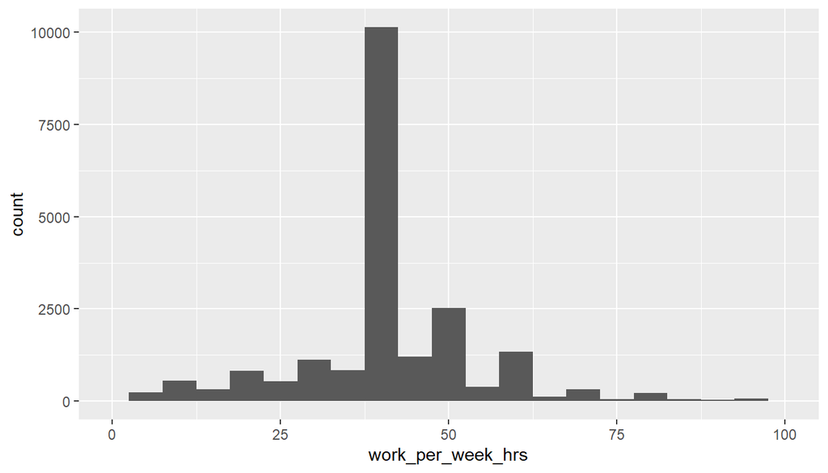

```r
project_d_f %>%
  ggplot(aes(x = work_per_week_hrs)) +
  geom_histogram(binwidth = 5) +
  xlim(0, 100)
```

```r
project_d_f %>%
  select(work_per_week_hrs) %>%
  filter(!is.na(work_per_week_hrs)) %>%
  summarize(Title = "work_per_week_hrs", n = n(), min = min(work_per_week_hrs), Q1 = quantile(work_per_week_hrs, 0.25), median = median(work_per_week_hrs), Q3 = quantile(work_per_week_hrs, 0.75), max = max(work_per_week_hrs))
```

```
##               Title     n min Q1 median Q3 max
## 1 work_per_week_hrs 21282   0 40     40 48 150
```

Sleep needs to be in the unit hours/week so it matches our work variable, to achieve this I created a new variable called sleep_per_week_hrs. It assumes that respondents sleep the same number of hours every night, which could be a source of error. For seeing if someone sleeps more than works a ratio of the two would be useful. Sleep to work ratio raises some issues because it divides by work per week hours which can be zero. To avoid dividing by zero I instead calculated work per sleep ratio and called it work_sleep_ratio.

```r
project_d_f <- project_d_f %>%
  mutate(sleep_per_week_hrs = sleep_per_day_hrs * 7, work_sleep_ratio = work_per_week_hrs / sleep_per_week_hrs)
```

This faceted histogram shows how the distributions of work_sleep_ratio for each factor in general_health. In order to show more of the bulk of the distribution some outliers are cropped out by the scaling of the plot.

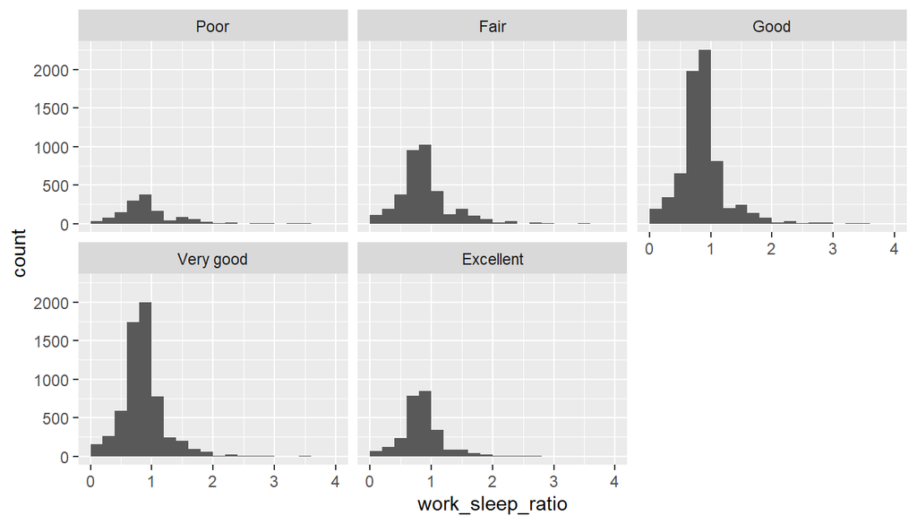

```r
project_d_f %>%
  select(general_health, work_sleep_ratio) %>%
  filter(!is.na(general_health) & !is.na(work_sleep_ratio)) %>%
  ggplot(aes(x = work_sleep_ratio)) +
    geom_histogram(binwidth = 0.2, boundary = 0) +
    xlim(0, 4) +
    facet_wrap(~ general_health)
```

This data is more right skewed across the board with means falling between 0.843 and 0.992 (meaning the average person spent more time sleeping than working) but some outliers working more than four times as many hours as they slept.

These side by side box-plots display the summary statistics of work_sleep_ratio for each health outcome. In order to show more of the boxes in more detail the distribution some outliers are cropped out by the scaling of the plot.

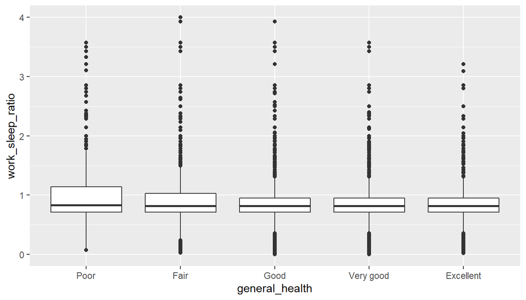

```r
project_d_f %>%
  select(general_health, work_sleep_ratio) %>%
  filter(!is.na(general_health) & !is.na(work_sleep_ratio)) %>%
  ggplot(mapping = aes(x = general_health, y = work_sleep_ratio)) +
    geom_boxplot() +
    ylim(0,4)
```

Here are the summary statistics of work_sleep_ratio for each health outcome.

```r
project_d_f %>%
  select(general_health, work_sleep_ratio) %>%
  filter(!is.na(general_health) & !is.na(work_sleep_ratio)) %>%
  group_by(general_health) %>%
  summarize(n = n(), min = min(work_sleep_ratio) %>% round(3), work = quantile(work_sleep_ratio, 0.25) %>% round(3), median = median(work_sleep_ratio) %>% round(3), mean = mean(work_sleep_ratio) %>% round(3), Q3 = quantile(work_sleep_ratio, 0.75) %>% round(3), max = max(work_sleep_ratio) %>% round(3), IQR = IQR(work_sleep_ratio) %>% round(3), sd = sd(work_sleep_ratio) %>% round(3))
```

```
## # A tibble: 5 x 10
##   general_health     n   min  work median  mean    Q3   max   IQR    sd
##   <fct>          <int> <dbl> <dbl>  <dbl> <dbl> <dbl> <dbl> <dbl> <dbl>
## 1 Poor            1365 0.071 0.714  0.857 0.992 1.14   9.29 0.429 0.696
## 2 Fair            3641 0.024 0.714  0.816 0.901 1.05   8.57 0.333 0.485
## 3 Good            7005 0     0.714  0.816 0.86  0.952  7.14 0.238 0.411
## 4 Very good       6178 0     0.714  0.816 0.85  0.952 14    0.238 0.436
## 5 Excellent       2670 0.02  0.714  0.816 0.843 0.952  4.67 0.238 0.352
```

Here there is a stronger correlation, this time in the negative direction, in the means between work_sleep_ratio and health outcomes. Again this correlation appears much weaker when examining the medians. In terms of my question this means there is a weak positive correlation between sleep to work ratio and health outcomes.

Again, this was a retrospective observational study with random sampling and not an experiment with random assignment therefore I did not assume causation. The relationship in the variables may be caused by a confounding variable. It is also worth noting potential issues with this data and assumptions made. In this case there were extreme responses for hours slept, I assumed that respondents slept the same number of hours every day, it is likely unpaid work was not reported, and I was relying on each respondents own self evaluation of health.

**Research question 3:**

Question 3 required calculating a total time spent exercising calculated as a function of four variables. Those were the frequency respondents partook in activities 1 and 2, and the amount of time spent on each activity per session. I examined each in turn before making any calculations.

Activity frequency recorded the responses to the question “How many times per week or per month did you take part in this activity during the past month?” for each of the two exercise activities the respondents indicated they most frequently participated in. Answers given as weekly frequency are coded with a 1 in the hundreds place, those given as monthly frequency were recorded with a 2 in the hundreds place.

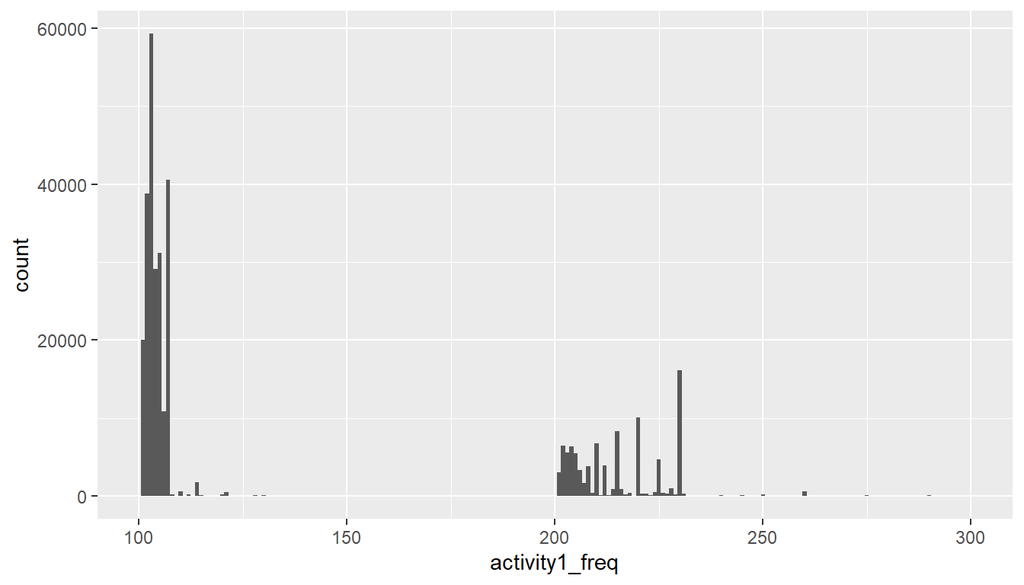

```r
project_d_f %>%
  ggplot(aes(x = activity1_freq)) +
  geom_histogram(binwidth = 1) +
  xlim(100, 300)
```

```r
project_d_f %>%
  select(activity1_freq) %>%
  filter(!is.na(activity1_freq)) %>%
  summarize(Title = "activity1_freq", n = n(), min = min(activity1_freq), Q1 = quantile(activity1_freq, 0.25), median = median(activity1_freq), Q3 = quantile(activity1_freq, 0.75), max = max(activity1_freq))
```

```
##            Title      n min  Q1 median  Q3 max
## 1 activity1_freq 327610   0 103    105 203 299
```

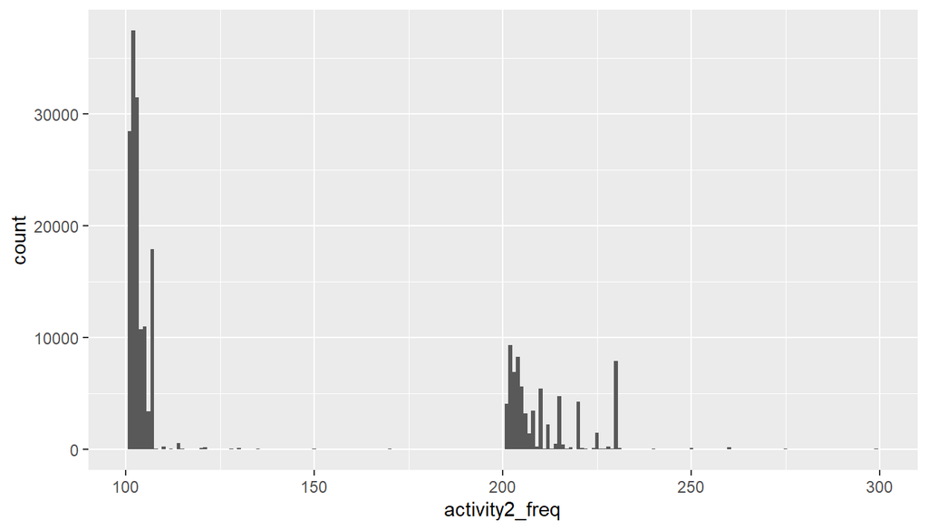

```r
project_d_f %>%
  ggplot(aes(x = activity2_freq)) +
  geom_histogram(binwidth = 1) +
  xlim(100, 300)
```

```r
project_d_f %>% select(activity2_freq) %>%
  filter(!is.na(activity2_freq)) %>%
  summarize(Title = "activity2_freq", n = n(), min = min(activity2_freq), Q1 = quantile(activity2_freq, 0.25), median = median(activity2_freq), Q3 = quantile(activity2_freq, 0.75), max = max(activity2_freq))
```

```
##            Title      n min  Q1 median  Q3 max
## 1 activity2_freq 213542   1 102    104 203 299
```

Activity duration recorded the responses to the question “And when you took part in this activity, for how many minutes or hours did you usually keep at it?” for each of the two exercise activities the respondents indicated they most frequently participated in. Answers given were recorded in hmm format where the hundreds place represents hours and the tens and ones places represent minutes.

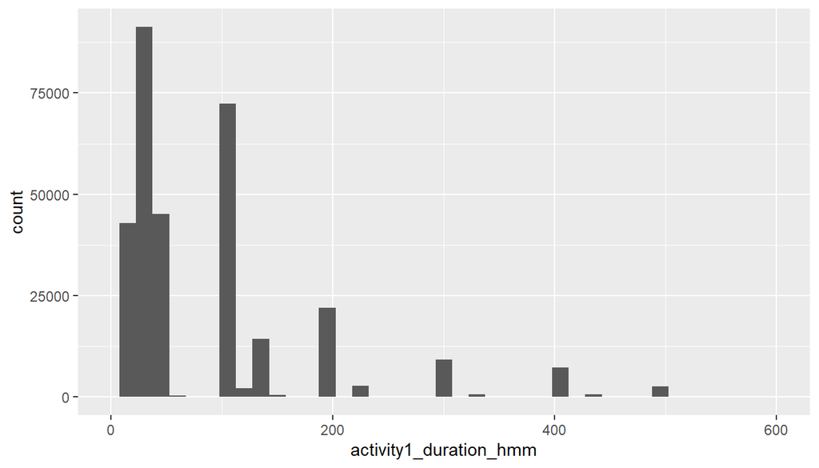

```r
project_d_f %>%
  ggplot(aes(x = activity1_duration_hmm)) +
  geom_histogram(binwidth = 15) +
  xlim(0, 600)
```

```r
project_d_f %>% select(activity1_duration_hmm) %>%
  filter(!is.na(activity1_duration_hmm)) %>%
  summarize(Title = "activity1_duration_hmm", n = n(), min = min(activity1_duration_hmm), Q1 = quantile(activity1_duration_hmm, 0.25), median = median(activity1_duration_hmm), Q3 = quantile(activity1_duration_hmm, 0.75), max = max(activity1_duration_hmm))
```

```
##                    Title      n min Q1 median  Q3 max
## 1 activity1_duration_hmm 323380   1 30     45 100 959
```

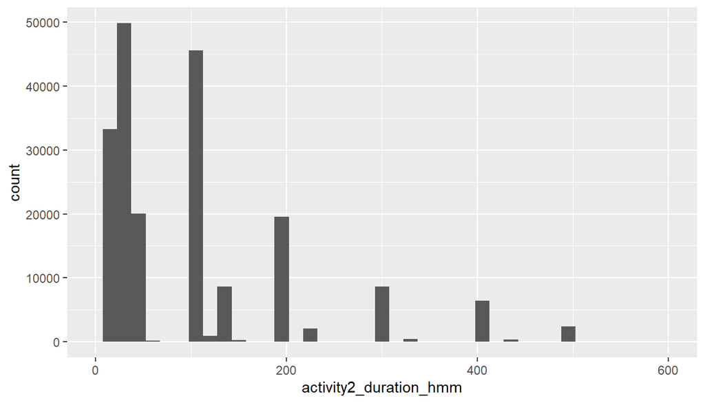

```r
project_d_f %>%
  ggplot(aes(x = activity2_duration_hmm)) +
  geom_histogram(binwidth = 15) +
  xlim(0, 600)
```

```r
project_d_f %>% select(activity2_duration_hmm) %>%
  filter(!is.na(activity2_duration_hmm)) %>%
  summarize(Title = "activity2_duration_hmm", n = n(), min = min(activity2_duration_hmm), Q1 = quantile(activity2_duration_hmm, 0.25), median = median(activity2_duration_hmm), Q3 = quantile(activity2_duration_hmm, 0.75), max = max(activity2_duration_hmm))
```

```
##                    Title      n min Q1 median  Q3 max
## 1 activity2_duration_hmm 208124   0 30     45 130 959
```

```r
# here I output short summaries of each of the new variables to get a feel for what I am working with.
```

Here I calculated hours exercised per week as a variable called exercise_per_week_hrs. Working backwards:

When examining the data the number of responses for activity 1 and activity 2 are different (more than one hundred thousand more responses were recorded for activity 1), this means that there are many cases where time spent on activity 1 has an integer value and activity 2 has a value of NA. In R math operations done with NA return NA so the code for this calculation had to be written such that if one of the values was NA the total value, exercise_per_week_hrs, would be set equal to the other value.

The total time spent on activities that exercise_per_week_hrs summed were calculated as activity1_per_week_hrs and activity2_per_week_hrs as the product of activity_freq_week and activity_duration_hmm.

activity_freq_week was calculated by determining whether the value of activity_freq was in units of times per week or times per month by checking whether it was between 100 and 200 or 200 and 300. If it was already in weekly format it was left unchanged, if it was in monthly format it was converted through division by four (this assumes exercise per month was evenly distributed by week), if it was neither a value of NA was returned.

```r
project_d_f <- project_d_f %>%
  mutate(activity1_freq_week = if_else(activity1_freq >= 100 & activity1_freq < 200, activity1_freq - 100, if_else(activity1_freq >= 200 & activity1_freq < 300, (activity1_freq - 200) / 4, as.numeric(NA)))) %>%
  mutate(activity2_freq_week = if_else(activity2_freq >= 100 & activity2_freq < 200, activity2_freq - 100, if_else(activity2_freq >= 200 & activity2_freq < 300, (activity2_freq - 200) / 4, as.numeric(NA)))) %>%
# activity frequency is stored such that the value right of the 100s place of values 0-199 represent times per week while the value right of the 100s place of values greater than 200 represent times per month. Here activity frequency was converted so all values represented weekly frequency.
  mutate(activity1_duration_hr = activity1_duration_hmm %/% 100 +  ((activity1_duration_hmm %% 100) / 60)) %>%
  mutate(activity2_duration_hr = activity2_duration_hmm %/% 100 +  ((activity2_duration_hmm %% 100) / 60)) %>%
# activity duration is stored with hours in the hundreds place and the digits to the right representing minutes. Here each activity time is converted to straight hours.
  mutate(activity1_per_week_hrs = activity1_freq_week * activity1_duration_hr) %>%
  mutate(activity2_per_week_hrs = activity2_freq_week * activity2_duration_hr) %>%
# here the total hours per week spent on each activity are calculated by multiplying frequency by duration
  mutate(exercise_per_week_hrs = if_else(!is.na(activity1_per_week_hrs) & !is.na(activity2_per_week_hrs), activity1_per_week_hrs + activity2_per_week_hrs, if_else(!is.na(activity1_per_week_hrs), activity1_per_week_hrs, activity2_per_week_hrs)))
# Both values of activity_per_week_hrs were added for a total value per week called exercise_per_week_hrs using if_else statements to ensure that NA values did not override the value if either activity had a frequency of NA.
```

After so much calculation I decided to take a look at the variable that was just calculated

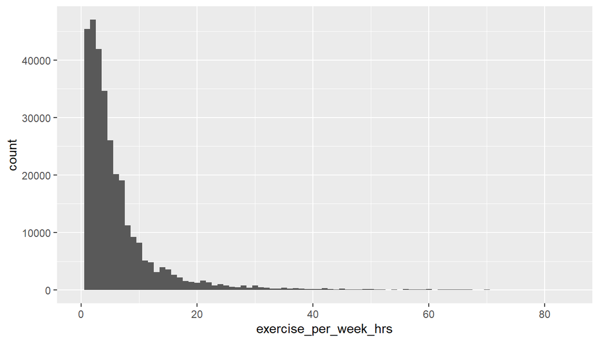

```r
project_d_f %>%
  ggplot(aes(x = exercise_per_week_hrs)) +
  geom_histogram(binwidth = 1) +
  xlim(0, 84)
```

```r
project_d_f %>% select(exercise_per_week_hrs) %>%
  filter(!is.na(exercise_per_week_hrs)) %>%
  summarize(Title = "exercise_per_week_hrs", n = n(), min = min(exercise_per_week_hrs), Q1 = quantile(exercise_per_week_hrs, 0.25), median = median(exercise_per_week_hrs), Q3 = quantile(exercise_per_week_hrs, 0.75), max = max(exercise_per_week_hrs))
```

```
##                   Title      n         min Q1 median    Q3    max
## 1 exercise_per_week_hrs 324181 0.004166667  2      4 7.125 748.75
```

I noticed that there were some responses greater than 168 hours, which is impossible without time travel, so I went back and made responses greater than 168 hours per week (the total hours in a week) NA. While I’m still skeptical about responses above 84 hours per week, or 12 hours per day, I will treat them as valid responses because they are at least possible and it is dangerous to just go deleting outliers.

```r
project_d_f <- project_d_f %>%
  mutate(exercise_per_week_hrs = if_else(exercise_per_week_hrs <= 168, exercise_per_week_hrs, as.numeric(NA)))
```

This faceted histogram shows how the distributions of exercise_per_week_hrs for each factor in general_health. In order to show more of the bulk of the distribution some outliers are cropped out by the scaling of the plot.

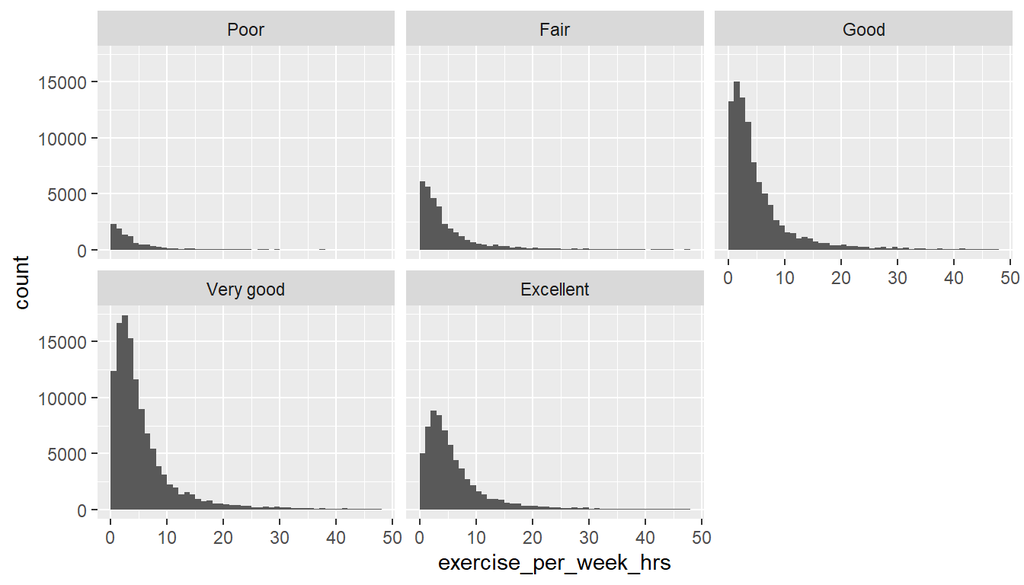

```r
project_d_f %>%
  select(general_health, exercise_per_week_hrs) %>%
  filter(!is.na(general_health) & !is.na(exercise_per_week_hrs)) %>%
  ggplot(aes(x = exercise_per_week_hrs)) +
    geom_histogram(binwidth = 1, boundary = 0) +
    xlim(0, 48) +
    facet_wrap(~ general_health)
```

The exercise vs health data is the most skewed with some extreme outliers pulling the distribution right, It appears some respondents reported exercising practically 24-7.

These side by side box-plots display the summary statistics of exercise_per_week_hrs for each health outcome. In order to show more of the boxes in more detail the distribution some outliers are cropped out by the scaling of the plot.

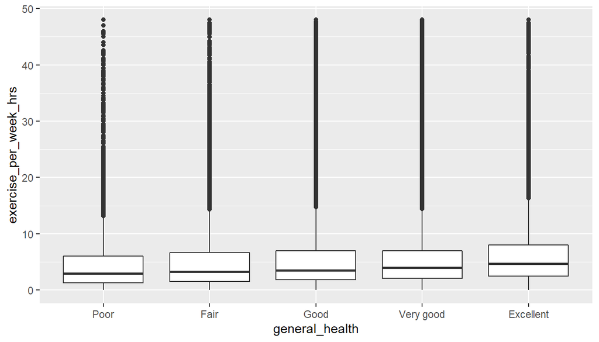

```r
project_d_f %>%
  select(general_health, exercise_per_week_hrs) %>%
  filter(!is.na(general_health) & !is.na(exercise_per_week_hrs)) %>%
  ggplot(mapping = aes(x = general_health, y = exercise_per_week_hrs)) +
    geom_boxplot() +
    ylim(0, 48)
```

```r
project_d_f %>%
  select(general_health, exercise_per_week_hrs) %>%
  filter(!is.na(general_health) & !is.na(exercise_per_week_hrs)) %>%
  group_by(general_health) %>%
  summarize(n = n(), min = min(exercise_per_week_hrs) %>% round(2), Q1 = quantile(exercise_per_week_hrs, 0.25) %>% round(2), median = median(exercise_per_week_hrs) %>% round(2), mean = mean(exercise_per_week_hrs) %>% round(2), Q3 = quantile(exercise_per_week_hrs, 0.75) %>% round(3), max = max(exercise_per_week_hrs) %>% round(2), IQR = IQR(exercise_per_week_hrs) %>% round(2), sd = sd(exercise_per_week_hrs) %>% round(2))
```

```
## # A tibble: 5 x 10
##   general_health      n   min    Q1 median  mean    Q3   max   IQR    sd
##   <fct>           <int> <dbl> <dbl>  <dbl> <dbl> <dbl> <dbl> <dbl> <dbl>
## 1 Poor            10284     0  1.25   3     5.6   6     140.  4.75  9.07
## 2 Fair            33435     0  1.5    3.25  5.91  6.94  152.  5.44  8.6
## 3 Good            94353     0  1.88   3.5   6     7     158.  5.12  8.03
## 4 Very good      118422     0  2.12   4     6.16  7     165   4.88  7.6
## 5 Excellent       66697     0  2.54   4.69  6.89  8     151.  5.46  8.04
```

Again, this was a retrospective observational study with random sampling and not an experiment with random assignment therefore I did not assume causation. The relationship in the variables may be caused by a confounding variable. It is also worth noting potential issues with this data and assumptions made. In this case there were some extreme responses for hours slept, I assumed the respondents only participated the two types of exercise they reported and that they were accurate in their reporting, and I was relying on each respondents own self evaluation of health.